# Экзамен

Казаков Данил

26 мая 2016 г.

# Задание 1

Необходимо исследовать на наличие линейной зависимости между факторами в датасете Cheese. Для каждого вида сыра собраны 4 характеристики: концентрации уксусной кислоты, молочной кислоты и сероводорода, а также общая оценка вкусовых качеств.

Первым делом посмотрим на графическое представление данных.

### Графическое представление данных.

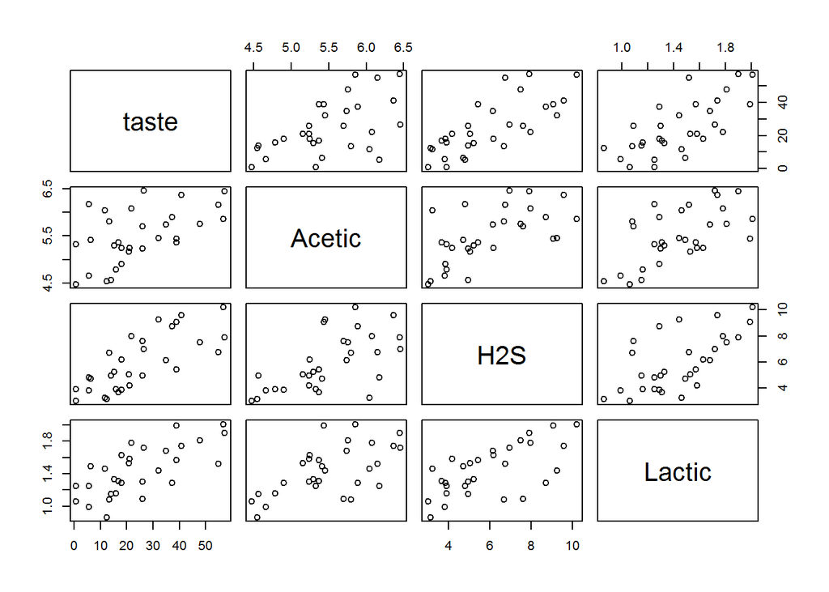

```r
cheese = read.table("1.txt", header = T)
cheese = cheese[, -1]
plot(cheese)
```

На первый взгляд можно сказать, что все факторы коррелируют между собой, т.к. на каждом графике нет явной рассеянности (левые верхние и правые нижние углы свободны). Обратимся к тестам.

### Тесты.

В качестве коэффицента корреляции возьмем коэффициент корреляции Пирсона, т.к. все данные измерены в шкале отношений.

#### taste

```r
cor.test( ~ taste + Acetic, data = cheese, method = "p")
```

```
##
##  Pearson's product-moment correlation
##
## data:  taste and Acetic
## t = 3.4806, df = 28, p-value = 0.001658
## alternative hypothesis: true correlation is not equal to 0
## 95 percent confidence interval:
##  0.2359923 0.7594509
## sample estimates:
##       cor
## 0.5495393
```

```r
cor.test( ~ taste + H2S,    data = cheese, method = "p")
```

```
##
##  Pearson's product-moment correlation
##
## data:  taste and H2S
## t = 6.1068, df = 28, p-value = 1.374e-06
## alternative hypothesis: true correlation is not equal to 0
## 95 percent confidence interval:
##  0.5434507 0.8771862
## sample estimates:
##       cor
## 0.7557523
```

```r
cor.test( ~ taste + Lactic, data = cheese, method = "p")
```

```
##
##  Pearson's product-moment correlation
##
## data:  taste and Lactic
## t = 5.2488, df = 28, p-value = 1.405e-05
## alternative hypothesis: true correlation is not equal to 0
## 95 percent confidence interval:
##  0.4609054 0.8490811
## sample estimates:
##       cor
## 0.7042362
```

Фактор $taste$ коррелирует со всем остальными факторами, т.е. вкус зависит от содержания молочной, уксусной кислот и сульфида водорода.

#### Acetic

```r
cor.test( ~ Acetic + H2S,    data = cheese, method  = "p")
```

```
##
##  Pearson's product-moment correlation
##
## data:  Acetic and H2S
## t = 4.1591, df = 28, p-value = 0.0002739
## alternative hypothesis: true correlation is not equal to 0
## 95 percent confidence interval:
##  0.3314855 0.8000988
## sample estimates:
##       cor
## 0.6179559
```

```r
cor.test( ~ Acetic + Lactic, data = cheese, method  = "p")
```

```
##
##  Pearson's product-moment correlation
##
## data:  Acetic and Lactic
## t = 4.0079, df = 28, p-value = 0.0004114
## alternative hypothesis: true correlation is not equal to 0
## 95 percent confidence interval:
##  0.3112089 0.7918132
## sample estimates:
##       cor
## 0.6037826
```

#### H2S

```r
cor.test( ~ H2S + Lactic, data = cheese, method = "p")
```

```
##
##  Pearson's product-moment correlation
##
## data:  H2S and Lactic
## t = 4.464, df = 28, p-value = 0.0001198
## alternative hypothesis: true correlation is not equal to 0
## 95 percent confidence interval:
##  0.3706465 0.8156103
## sample estimates:
##       cor
## 0.6448123
```

По результатам тестов, факторы $Acetic$, $H2S$ и $Lactic$ коррелируют между собой. Можно предположить, что все химические элементы присутствуют в одном процессе. Например, молочная кислота быстро окисляется до уксусной кислоты. Значит, при одной и той же технологии изготовления сыра при увеличении концентрации молочной кислоты будет увеличиваться содержание уксусной кислоты.

# Задача 2

Необходимо построить модель зависимости расходов на душу населения и общественные нужды от характеристик населения в штатах.

#### Построим простую модель.

```r
library(MASS)
expend = read.table("2.txt", header = T)
expend$WEST = as.factor(expend$WEST)

res.1 = lm(EX ~ ECAB + MET + GROW + YOUNG + OLD + WEST, data = expend)
summary(res.1)
```

```
##
## Call:
## lm(formula = EX ~ ECAB + MET + GROW + YOUNG + OLD + WEST, data = expend)
##
## Residuals:
##     Min      1Q  Median      3Q     Max
## -75.031 -26.226   0.296  23.256  87.653
##
## Coefficients:
##             Estimate Std. Error t value Pr(>|t|)
## (Intercept) 356.1818   306.4862   1.162  0.25190
## ECAB          1.4185     0.4300   3.298  0.00202 **
## MET          -0.6602     0.3526  -1.872  0.06832 .
## GROW          0.5716     0.4251   1.345  0.18615
## YOUNG        -6.6747     7.4806  -0.892  0.37746
## OLD          -1.8551     7.1368  -0.260  0.79622
## WEST1        35.4723    13.7711   2.576  0.01370 *
## ---
## Signif. codes:  0 '***' 0.001 '**' 0.01 '*' 0.05 '.' 0.1 ' ' 1
##
## Residual standard error: 39.84 on 41 degrees of freedom
## Multiple R-squared:  0.5994, Adjusted R-squared:  0.5408
## F-statistic: 10.22 on 6 and 41 DF,  p-value: 6.634e-07
```

Довольно маленький коэффициент $R^2$. Первое замечание: модель нелинейна. Посмотрим на графики.

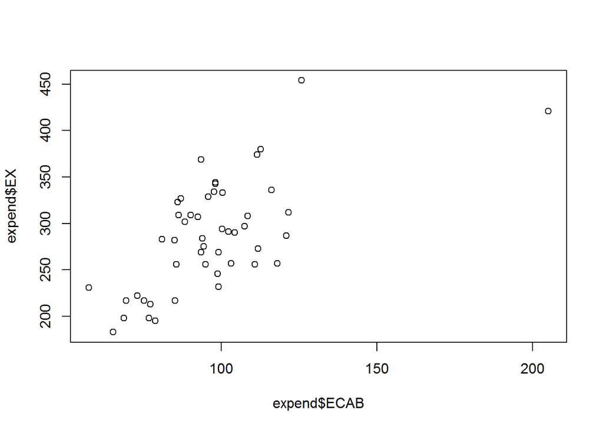

```r
plot(expend$ECAB, expend$EX)
```

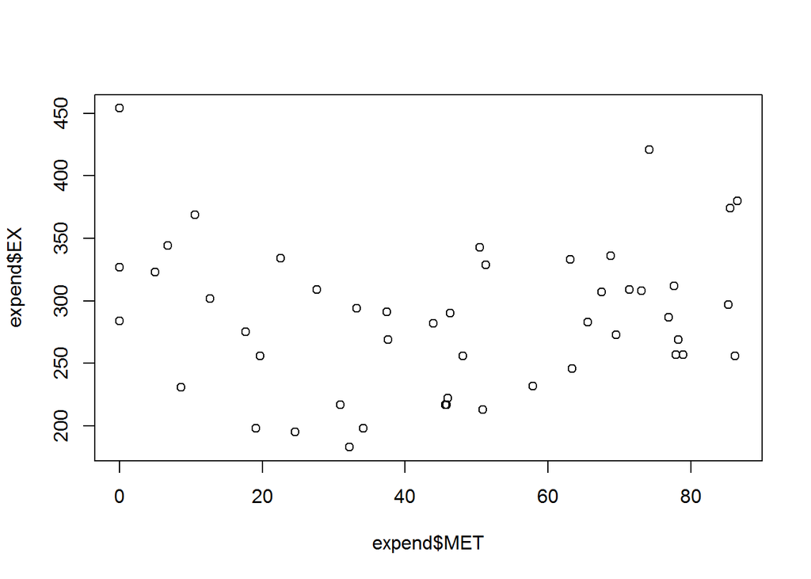

```r
plot(expend$MET, expend$EX)
```

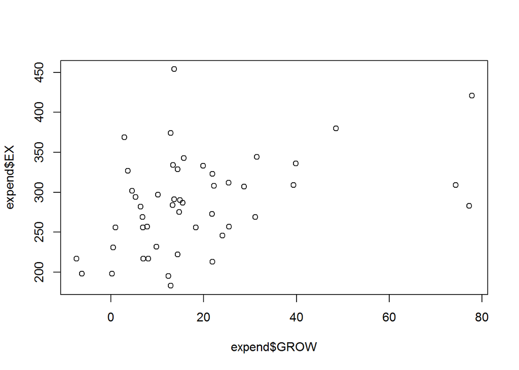

```r
plot(expend$GROW, expend$EX)
```

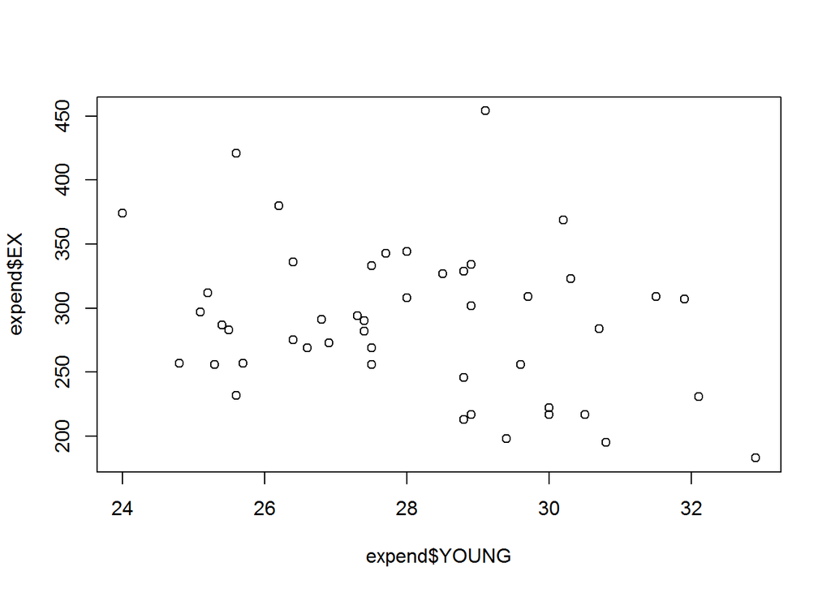

```r
plot(expend$YOUNG, expend$EX)
```

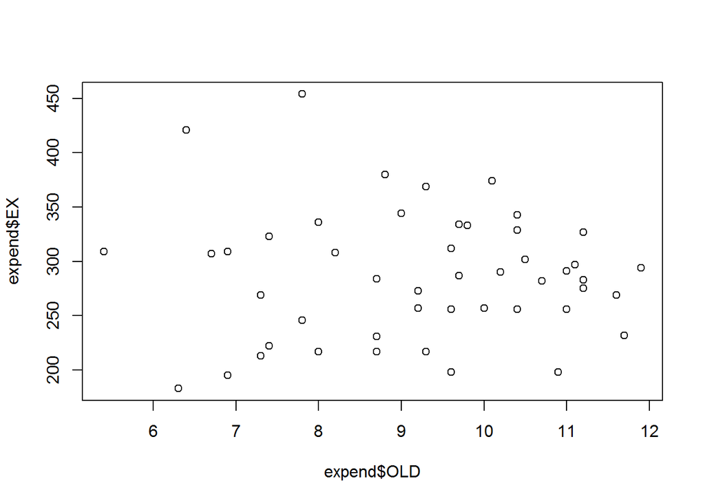

```r
plot(expend$OLD, expend$EX)
```

В данных $ECAB$ и $GROW$ наблюдаются выбросы (намек на робастную линейную регрессию). На графике зависимости можно заметить, что $MET$ зависит от $EX$ квадратично. Построим новую модель.

```r
MET2 = expend$MET^2
expend = data.frame(expend, MET2)

res.2 = lm(EX ~ ECAB + MET + MET2 + GROW + YOUNG + OLD + WEST, data = expend)
summary(res.2)
```

```
##
## Call:
## lm(formula = EX ~ ECAB + MET + MET2 + GROW + YOUNG + OLD + WEST,
##     data = expend)
##
## Residuals:
##     Min      1Q  Median      3Q     Max
## -63.974 -16.620  -2.647  20.898  68.234
##
## Coefficients:
##               Estimate Std. Error t value Pr(>|t|)
## (Intercept) 119.118461 280.911921   0.424 0.673807
## ECAB          1.395420   0.382255   3.650 0.000749 ***
## MET          -3.042142   0.758040  -4.013 0.000256 ***
## MET2          0.030914   0.008958   3.451 0.001332 **
## GROW          0.695336   0.379504   1.832 0.074371 .
## YOUNG         0.607602   6.975082   0.087 0.931018
## OLD           4.120784   6.574827   0.627 0.534383
## WEST1        34.073079  12.245464   2.783 0.008192 **
## ---
## Signif. codes:  0 '***' 0.001 '**' 0.01 '*' 0.05 '.' 0.1 ' ' 1
##
## Residual standard error: 35.41 on 40 degrees of freedom
## Multiple R-squared:  0.6913, Adjusted R-squared:  0.6373
## F-statistic:  12.8 on 7 and 40 DF,  p-value: 1.717e-08
```

Модель стала явно лучше. Отбросим неинформативные переменные: $OLD$ и $YOUNG$

```r
res.3 = lm(EX ~ ECAB + MET + MET2 + GROW + WEST, data = expend)
summary(res.3)
```

```
##
## Call:
## lm(formula = EX ~ ECAB + MET + MET2 + GROW + WEST, data = expend)
##
## Residuals:
##     Min      1Q  Median      3Q     Max
## -64.994 -18.465  -0.979  20.315  68.539
##
## Coefficients:
##               Estimate Std. Error t value Pr(>|t|)
## (Intercept) 174.328471  29.227629   5.965 4.47e-07 ***
## ECAB          1.414801   0.283863   4.984 1.12e-05 ***
## MET          -2.999960   0.748307  -4.009 0.000245 ***
## MET2          0.030534   0.008441   3.617 0.000793 ***
## GROW          0.517016   0.322546   1.603 0.116447
## WEST1        34.939366  11.207068   3.118 0.003286 **
## ---
## Signif. codes:  0 '***' 0.001 '**' 0.01 '*' 0.05 '.' 0.1 ' ' 1
##
## Residual standard error: 35.01 on 42 degrees of freedom
## Multiple R-squared:  0.6831, Adjusted R-squared:  0.6454
## F-statistic: 18.11 on 5 and 42 DF,  p-value: 1.522e-09
```

Коэффициент $R^2$ уменьшился незначительно.

#### Анализ остатков

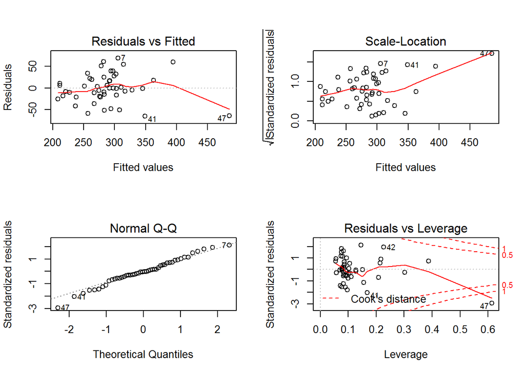

```r
layout(matrix(c(1,2,3,4),2,2))
plot(res.3)
```

В целом, наши стандартные предположения о модели выполняются, но в наших данных есть выбросы. Построим робастную регрессию с M-оценками с функцией Хубера.

```r
res.rlm = rlm(EX ~ ECAB + MET + MET2 + GROW + WEST, data = expend)
summary(res.rlm)
```

```
##
## Call: rlm(formula = EX ~ ECAB + MET + MET2 + GROW + WEST, data = expend)
## Residuals:
##      Min       1Q   Median       3Q      Max
## -103.840  -15.292   -2.945   17.733   71.848
##
## Coefficients:
##             Value    Std. Error t value
## (Intercept) 146.8801  28.1946     5.2095
## ECAB          1.7090   0.2738     6.2410
## MET          -2.9071   0.7219    -4.0273
## MET2          0.0279   0.0081     3.4314
## GROW          0.6991   0.3111     2.2469
## WEST1        35.1021  10.8110     3.2469
##
## Residual standard error: 24.52 on 42 degrees of freedom
```